# Figures worth showing

Supplement 1 | PCB 6455 / BSC 4933: Biometry

Author

Dr. Brian Maitner

## This is optional

A supplement, not a lecture. Nothing here will be on an exam, nothing here is due, and you can work through it whenever it becomes useful.

**Every code block here is meant to be run.** There is no “watch this one”: if it is on the page, you can paste it into R and get the figure next to it.

*Last checked: 2026-10-16, with ggplot2 4.0.3, ggridges 0.5.7, ggbump 0.1.99, patchwork 1.3.2, glyospalettes 0.2.2, transformerpalettes 0.2.0.*

## What you need

```r
install.packages(c("ggplot2", "ggridges", "ggbump", "patchwork",
                   "viridis", "colorspace"))
```

Then:

```r
library(ggplot2)
library(ggridges)
library(ggbump)
library(patchwork)
```

## The data

Three tables from the course repository. They are already tidy, so nothing here is about wrangling.

```r
base <- "https://github.com/bmaitner/biometry_course/raw/refs/heads/main/data/class_examples/"

reef <- read.csv(paste0(base, "reef_surveys.csv"))
ranks <- read.csv(paste0(base, "bbs_species_ranks.csv"))
occ <- read.csv(paste0(base, "bobwhite_occupancy.csv"))

dim(reef)
```

```
[1] 8560    8
```

`reef` is 8,560 NCRMP reef fish surveys, with depth, species richness and habitat. `ranks` is the six commonest Florida birds in each year. `occ` is bobwhite occupancy of Breeding Bird Survey routes, one row per year.

# Part 1: Color

## The default palette is not a choice

ggplot2 picks colors by walking evenly around a color wheel. That is a reasonable default and a poor decision, because it ignores everything about your data.

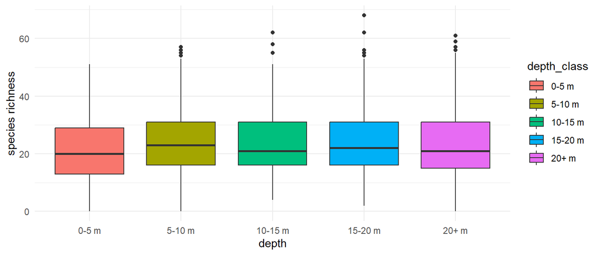

```r
reef$depth_class <- cut(reef$depth, c(0, 5, 10, 15, 20, 35),
                        labels = c("0-5 m", "5-10 m", "10-15 m",
                                   "15-20 m", "20+ m"))

ggplot(reef, aes(depth_class, richness, fill = depth_class)) +
  geom_boxplot() +
  theme_minimal() +
  labs(x = "depth", y = "species richness")
```

## Three kinds of data, three kinds of palette

The single most useful idea in this supplement:

| Your variable | Palette type | Example |
| --- | --- | --- |
| unordered groups: habitat, species, treatment | **qualitative**, distinct hues | `scale_fill_viridis_d()` |
| ordered or continuous: depth, temperature, year | **sequential**, one hue, light to dark | `scale_fill_viridis_c()` |
| a meaningful midpoint: change, difference, residual | **diverging**, two hues either side of pale | `scale_fill_gradient2()` |

Depth classes above are **ordered**, so the five unrelated hues are actively misleading. They suggest five unrelated categories.

## The same plot, honestly colored

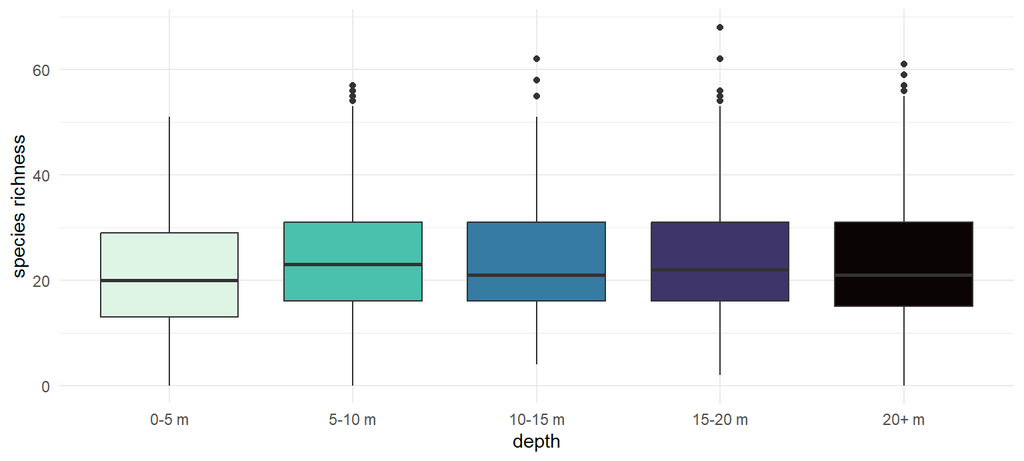

```r
ggplot(reef, aes(depth_class, richness, fill = depth_class)) +
  geom_boxplot() +
  scale_fill_viridis_d(option = "mako", direction = -1, guide = "none") +
  theme_minimal() +
  labs(x = "depth", y = "species richness")
```

The color now carries the same information as the x axis: deeper is darker. `direction = -1` is doing real work there, because mako runs dark to light by default, which would have put the darkest color on the shallowest water.

Since the color duplicates the axis, the legend is dropped with `guide = "none"`.

## Why viridis

The viridis palettes are built so that equal steps in the data look like equal steps in color. Most palettes are not, which is why the rainbow invents stripes that are not in your data.

Three practical consequences:

- **It survives being printed in black and white**, because lightness increases steadily along the scale
- **It survives color blindness**, for the same reason
- **It does not create false boundaries**, so a smooth gradient looks smooth

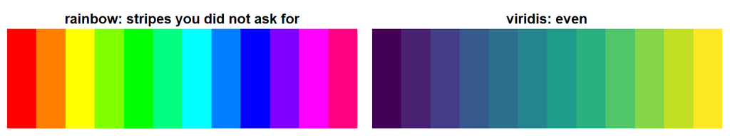

## Checking for color blindness

You do not have to guess. `colorspace` simulates how colors look to someone with the commonest form of color blindness, which affects roughly 1 in 12 men.

[figure not shown]

```r
library(colorspace)

default_hues <- scales::hue_pal()(5)
mako <- viridis::viridis(5, option = "mako")

swatchplot(list("ggplot default"     = default_hues,
                "    deuteranopia"   = deutan(default_hues),
                "viridis mako"       = mako,
                "    deuteranopia"   = deutan(mako)))
```

## What that showed

Three of the five default colors collapse into near-identical olive:

```r
rbind(default = default_hues, deuteranopia = deutan(default_hues))[, 1:3]
```

```
             [,1]      [,2]      [,3]
default      "#F8766D" "#A3A500" "#00BF7D"
deuteranopia "#B6A86A" "#B4A11C" "#AAA281"
```

Those are the red, the yellow-green and the green. In the boxplot two slides back, three of the five boxes become the same color.

The mako scale survives, because it never relied on hue to carry the order. It used **lightness**, and lightness is unaffected.

**That is the real argument for ordered palettes**: they degrade gracefully. A palette that separates groups by hue alone has a single point of failure.

## Checking a whole figure

To check a finished figure rather than a palette, `colorspace` ships an interactive viewer. Run this and paste in a saved image:

```r
colorspace::cvd_emulator()
```

A quicker habit, and the one actually worth building: **print it in black and white.** If the figure still works in greyscale, it will survive any form of color blindness, because you have stopped relying on hue.

## Palettes from outside CRAN

Not everything useful is on CRAN. Packages under development, specialist tools, and anything written by someone in your lab usually live on GitHub, and `remotes` installs them directly:

```r
install.packages("remotes")

remotes::install_github("bmaitner/glyospalettes")
remotes::install_github("bmaitner/transformerpalettes")
```

```r
library(glyospalettes)
library(transformerpalettes)
```

**One caution worth absorbing:** installing from GitHub runs code written by whoever owns that repository, with no review in between. CRAN at least checks that a package builds and does not do anything obviously hostile. Install from GitHub when you know whose repository it is.

## Fun palettes, serious diagnostics

Both packages take their colors from toy lines: the Glyos figures and Generation 1 Transformers. The colors are the lighthearted part.

The tools underneath are not. They are the clearest demonstration of Part 1’s argument, because **a palette chosen to look good on a toy is not automatically readable on a chart**, and these ship what you need to tell the difference.

```r
glyos_palette_stats("glyaxia")[, c("n_colours", "min_de", "min_de_deutan",
                                   "lum_range", "colorblind", "sequential")]
```

```
  n_colours   min_de min_de_deutan lum_range colorblind sequential
1         5 24.01187      24.05165  61.67492       TRUE      FALSE
```

## Reading that output

Every column is a question from Part 1, answered with a number:

| Column | The question it answers |
| --- | --- |
| `min_de` | How far apart are the two **closest** colors? Under about 10, they get confused |
| `min_de_deutan` | The same, under color blindness. Passing the first and failing this means it separates by hue alone |
| `lum_range` | How much **lightness** does it span? This is what survives greyscale |
| `colorblind`, `sequential` | Verdicts, from thresholds on the columns above |

**This is the useful part.** The thresholds are rules of thumb, but the quantities are the real criteria, and they apply to any palette from any source.

## Shortlisting

Rather than reading stats for 193 palettes, ask for the ones that pass:

```r
head(glyos_find_palettes("sequential"), 6)
```

```
[1] "eclipse"           "ultra_corps"       "frontier"
[4] "callgrim_standard" "neo_frontier"      "villser"
```

```r
head(tf_find_palettes("colorblind"), 6)
```

```
[1] "blades"      "computron"   "air_raid"    "superion"    "scattershot"
[6] "fireflight"
```

Then look at them, because passing a numeric check is not the same as being a good choice.

## Colors that survive your background

The most useful tool in either package. A color that reads on a white slide can vanish on a dark one, and `tf_pick()` answers that directly:

```
Transformers pick of 3 colours from optimus_prime
light background #FFFFFF, colorblind-safe, min distance 25.2
optimus_prime = #D0202A
optimus_prime = #1F3E8F
optimus_prime = #2D2D2D
```

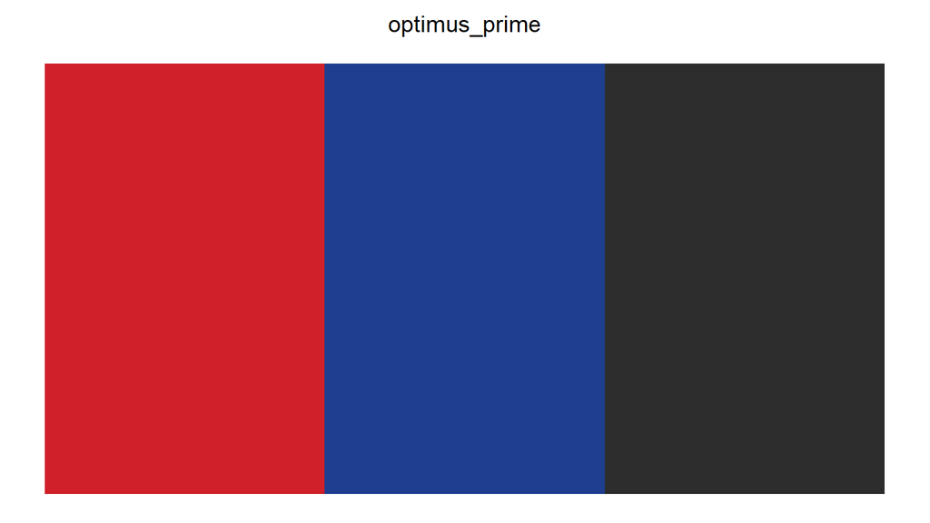

```r
tf_pick("optimus_prime", n = 3, style = "light", colorblind = TRUE)
```

On white it keeps the red, the navy and the near-black, dropping the silver and the gold as too pale to see.

## The same palette, a dark background

```
Transformers pick of 3 colours from optimus_prime
dark background #121212, min distance 76.7
optimus_prime = #D0202A
optimus_prime = #F2D23C
optimus_prime = #B8BABF
```

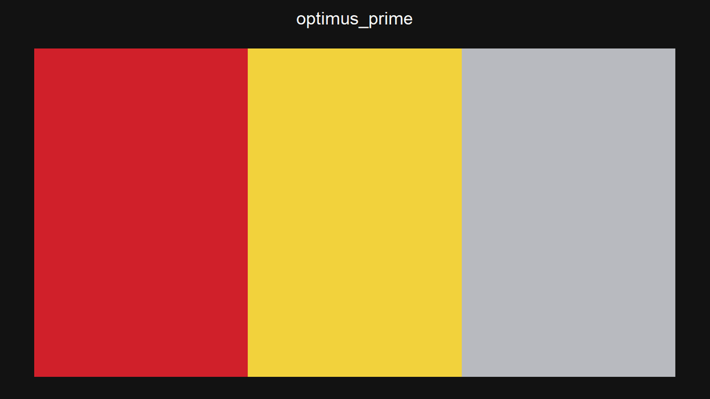

```r
tf_pick("optimus_prime", n = 3, style = "dark")
```

Now the navy and the black are gone, and the silver and gold are in.

**Same five colors in, a different three out.** Which colors work is a property of the palette *and* the background together, which is why a figure that looked fine in RStudio can be unreadable projected on a dark theme.

## Using any palette, from any source

`scale_fill_manual()` takes a vector of colors, so this works for these packages, for a journal’s house colors, or for hex codes off a website:

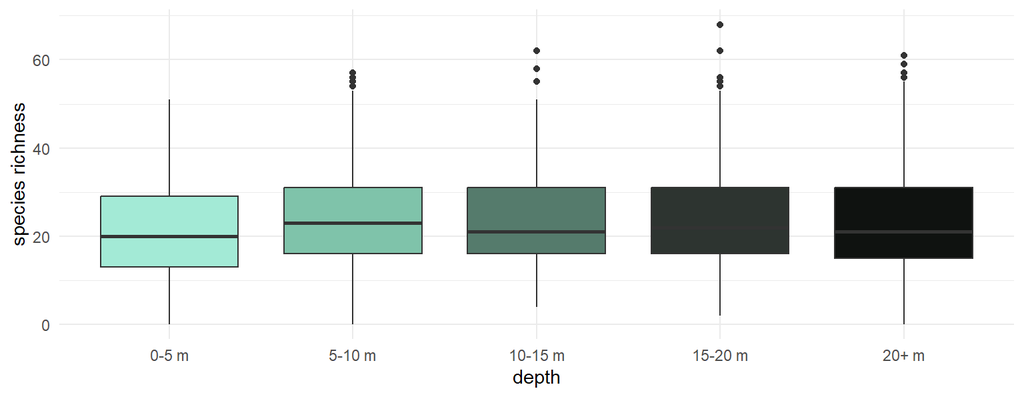

```r
hades <- rev(as.character(glyos_palette("hades", 5, type = "continuous",
                                        sort = TRUE)))

ggplot(reef, aes(depth_class, richness, fill = depth_class)) +
  geom_boxplot() +
  scale_fill_manual(values = hades, guide = "none") +
  theme_minimal() +
  labs(x = "depth", y = "species richness")
```

`type = "continuous"` interpolates the four-color palette to the five we need, and `sort = TRUE` orders it by lightness. `rev()` then puts the dark end on the deep water, matching the mako version earlier.

Getting that direction right is a surprisingly easy thing to get wrong, and the figure still looks perfectly professional when it is backward.

## Putting it to work

`tf_pick()` gave us three colors that hold up on a white slide. Here they are doing a real job, on how many reef surveys fall in each protection category:

[figure not shown]

```r
reef$protection_f <- factor(reef$protection, levels = c(0, 1, 2),
                            labels = c("Unprotected", "Protected", "Research only"))

prime <- as.character(tf_pick("optimus_prime", n = 3, style = "light",
                              colorblind = TRUE))

ggplot(reef, aes(protection_f, fill = protection_f)) +
  geom_bar() +
  scale_fill_manual(values = prime, guide = "none") +
  theme_minimal() +
  labs(x = NULL, y = "surveys",
       title = "Colorway: Optimus Prime (G1, 1984)")
```

## Now one from Glyos

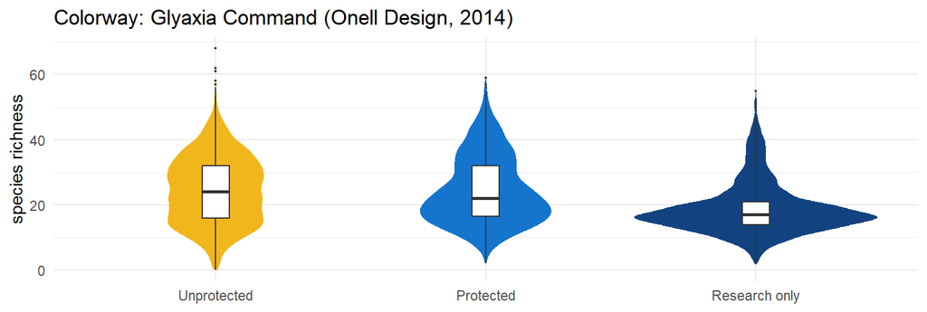

```r
glyaxia <- as.character(glyos_palette("glyaxia", 3))

ggplot(reef, aes(protection_f, richness, fill = protection_f)) +
  geom_violin(colour = NA) +
  geom_boxplot(width = 0.1, fill = "white", outlier.size = 0.3) +
  scale_fill_manual(values = glyaxia, guide = "none") +
  theme_minimal() +
  labs(x = NULL, y = "species richness",
       title = "Colorway: Glyaxia Command (Onell Design, 2014)")
```

## The object the colors came from

[figure not shown]

Glyan, Glyaxia Command colorway, Onell Design, 2014. Photo: Official Glyos Database, https://database.glyos.com/2014/05/glyan-glyaxia-standard.html

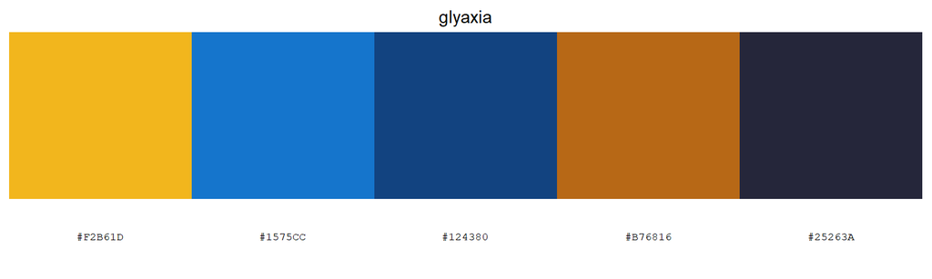

Yellow and blue plastic, black visor. Those are the five colors in the palette, and the three used in the violin plot on the previous slide.

## One more, from Transformers

[figure not shown]

Megatron, Generation 1 toy, 1984. Photo: TFWiki, https://tfwiki.net/wiki/Megatron_(G1)/toys

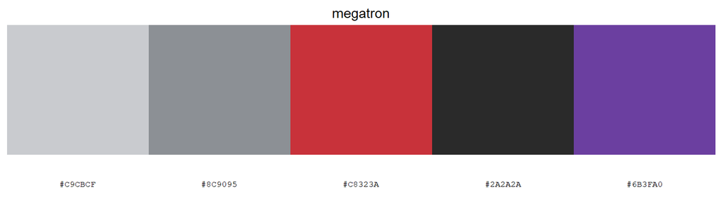

Chromed silver, grey, red, black, and a purple insignia. A perfectly usable five-color categorical palette that happens to be a 1984 toy.

## Finding these yourself

Both packages carry the provenance in their data, so you never have to guess which object a palette came from:

```r
glyos_colorways[glyos_colorways$palette == "glyaxia",
                c("colorway", "year", "source")]
```

```
         colorway year
7 Glyaxia Command 2014
                                                          source
7 https://database.glyos.com/2014/05/glyan-glyaxia-standard.html
```

```r
tf_characters[tf_characters$palette == "megatron",
              c("character", "year", "source")]
```

[output not shown]

Naming the colorway in a figure title, as on the previous slides, is a small thing that makes a plot memorable in a talk, and it means that six months later you know exactly how to reproduce the colors.

# Part 2: Showing a distribution per group

## The problem

Lecture 12 made the point that a single histogram can hide structure: if two groups have different distributions, the pooled histogram is some third shape belonging to nobody.

The usual fix is a boxplot, which shows the median and spread but **hides the shape**. A bimodal group and a flat group can give identical boxes.

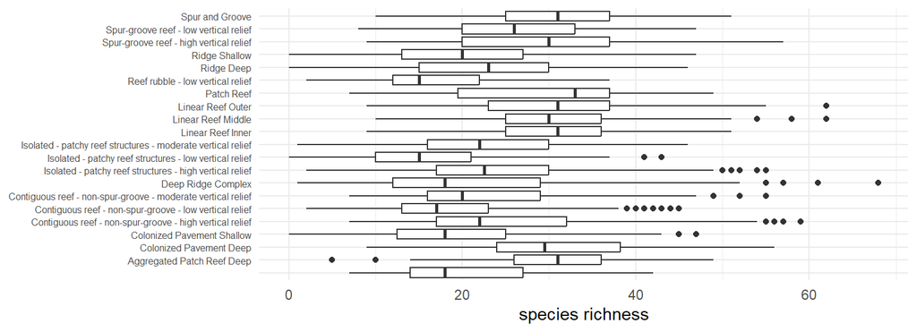

```r
ggplot(reef, aes(habitat, richness)) +
  geom_boxplot() +
  coord_flip() +
  theme_minimal() +
  theme(axis.text.y = element_text(size = 6)) +
  labs(x = NULL, y = "species richness")
```

## Violins: the shape, without the stacking

A violin is a density, mirrored. It shows what the boxplot hides, in the same space the boxplot used:

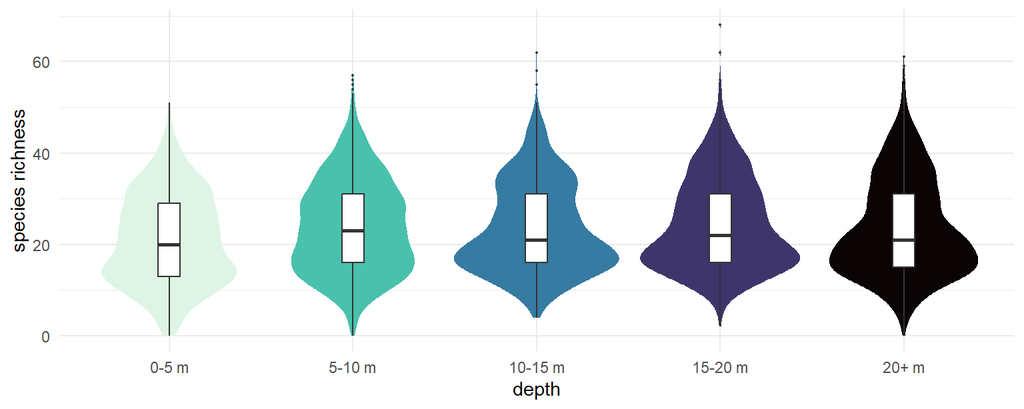

```r
ggplot(reef, aes(depth_class, richness, fill = depth_class)) +
  geom_violin(colour = NA) +
  geom_boxplot(width = 0.12, fill = "white", outlier.size = 0.3) +
  scale_fill_viridis_d(option = "mako", direction = -1, guide = "none") +
  theme_minimal() +
  labs(x = "depth", y = "species richness")
```

The white boxplot inside is the standard pairing: the violin carries the shape, the box carries the median and quartiles, and you give up neither.

## Ridgelines show the shape

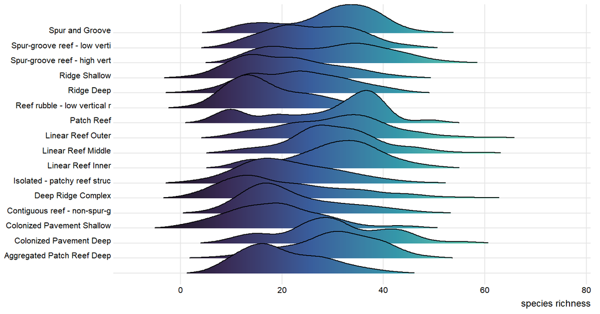

```r
reef$habitat_short <- substr(reef$habitat, 1, 28)

ggplot(reef, aes(x = richness, y = habitat_short, fill = after_stat(x))) +
  geom_density_ridges_gradient(scale = 2.2, rel_min_height = 0.01) +
  scale_fill_viridis_c(option = "mako", guide = "none") +
  theme_ridges(font_size = 9) +
  labs(x = "species richness", y = NULL)
```

## What that figure is worth

The boxplot said these habitats differ in median richness. The ridgeline says more:

- Some habitats are **tightly peaked**, others spread across the whole range
- Some are **skewed**, with a long tail of unusually rich surveys
- The differences between habitats are **small relative to the variation within** each one, which a boxplot tends to understate

That last point is the one that changes conclusions, and it is invisible in a plot of medians.

**Use a boxplot when center and spread are all you need, and a violin or a ridgeline when the shape is part of the finding.** Which of those two depends mostly on how many groups you have, which is the next slide.

## The y axis does not have to be a category

In the habitat plot the vertical axis was just a list of labels, in whatever order. When your groups come from a **number**, map the ridges to that number and the spacing carries information too:

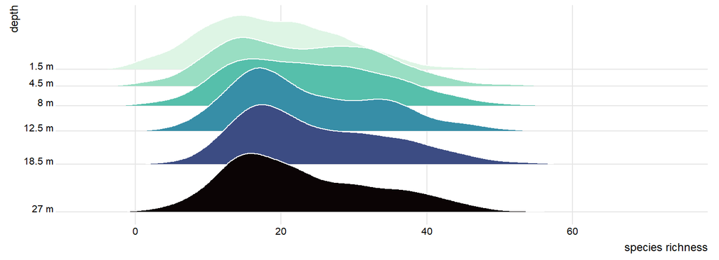

```r
brk <- c(0, 3, 6, 10, 15, 22, 32)
mid <- (head(brk, -1) + tail(brk, -1)) / 2
reef$band_mid <- mid[as.integer(cut(reef$depth, brk))]

ggplot(subset(reef, !is.na(band_mid)),
       aes(x = richness, y = -band_mid, group = band_mid, fill = -band_mid)) +
  geom_density_ridges(scale = 2.2, rel_min_height = 0.01, colour = "white") +
  scale_y_continuous(breaks = -mid, labels = paste0(mid, " m")) +
  scale_fill_viridis_c(option = "mako", guide = "none") +
  theme_ridges(font_size = 9) +
  labs(x = "species richness", y = "depth")
```

## What that buys

The figure is now a **cross-section of the reef**. Shallow water is at the top, deep water at the bottom, because `y = -band_mid` puts depth where depth actually is.

. . .

And the **gaps are real**. The 1.5 m and 4.5 m ridges nearly touch because those bands are three metres apart; the 18.5 m and 27 m ridges sit far apart because they are. An evenly spaced categorical axis would have thrown that away and implied the bands were equally separated.

. . .

The same trick works for **elevation up a mountainside**, distance along a transect, or time. Whenever the groups are slices of a continuous thing, let the axis say so.

Worth pausing on, because it is the difference between a figure that displays groups and one that displays a gradient.

## Three ways, and when to reach for each

They are the same idea at three levels of detail, and the right choice is mostly about how many groups you have:

| Plot | Shows | Reach for it when |
| --- | --- | --- |
| **Boxplot** | five numbers | many groups, and center and spread are all you need |
| **Violin** | the full shape, mirrored | a handful of groups, and the shape matters |
| **Ridgeline** | the full shape, stacked | many groups, and the shape still matters |

Violins get crowded past about eight groups, which is the point where ridgelines take over: stacking them vertically buys room that mirroring does not.

# Part 3: Parts of a whole

## Pie charts

A pie is a stacked bar in polar coordinates, which is exactly how you build one:

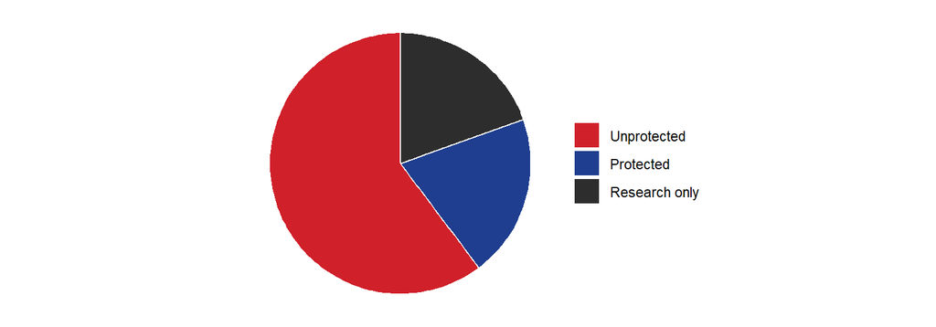

```r
prot_counts <- as.data.frame(table(reef$protection_f))
names(prot_counts) <- c("protection", "n")

ggplot(prot_counts, aes(x = "", y = n, fill = protection)) +
  geom_col(width = 1, colour = "white") +
  coord_polar(theta = "y") +
  scale_fill_manual(values = prime) +
  theme_void() +
  labs(fill = NULL)
```

## And a donut

Same code, with the bar pushed away from the center so the middle is empty:

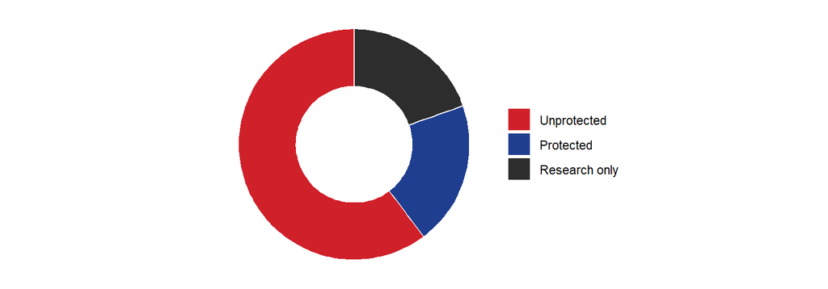

```r
ggplot(prot_counts, aes(x = 2, y = n, fill = protection)) +
  geom_col(width = 1, colour = "white") +
  coord_polar(theta = "y") +
  xlim(0.5, 2.5) +
  scale_fill_manual(values = prime) +
  theme_void() +
  labs(fill = NULL)
```

## What the hole costs, or does not

The standard advice goes: a pie asks you to compare **angles**, people are bad at angles, and a donut is worse still because removing the center removes the angle.

. . .

**The evidence does not support that.** Skau and Kosara (2016) built pies and donuts that isolated each cue, arc length, center angle and segment area, and varied the donut’s inner radius from a filled pie down to a thin ring.

- **Angle was the least important cue** in both chart types
- **Donuts were read about as accurately as pies**

. . .

So if you prefer the look of a donut, the research does not say you are hurting your reader. Pick either.

. . .

Worth noticing what just happened: a confident, widely repeated design rule turned out to be mostly folklore once somebody ran the experiment. Figure advice is full of that, which is a good reason to check the ones you repeat.

## Why a bar chart still wins

Cleveland and McGill ranked how accurately people read different visual encodings. Most accurate first:

1. **Position** along a common scale
2. Position on non-aligned scales
3. **Length**, direction, angle
4. **Area**
5. Volume, curvature
6. **Shading and color saturation**

. . .

A bar chart puts your numbers at **rank 1**. A pie or donut puts them at 3 and 4. That is the real argument, and it has nothing to do with the hole.

Cleveland, W.S. and McGill, R. (1984). Graphical perception: theory, experimentation, and application to the development of graphical methods. *Journal of the American Statistical Association* 79(387), 531-554. doi:10.1080/01621459.1984.10478080

## Two things to take from that list

**Color is last.** Everything in Part 1 was about an encoding at the bottom of the ranking. That is not an argument against caring about color, it is an argument for not asking color to carry the finding on its own. Use it to support a position or length encoding, not to replace one.

. . .

**Treat it as a strong guide, not a law.** The ordering began as a hypothesis their experiments were designed to test, and later work suggests it collapses to fewer tiers depending on the task. It earns its keep as a default, which is different from a proof.

. . .

What also survives, for pies specifically: **comparing across two pies is hard** in a way comparing two bar charts is not, and **both fail with many categories**, which is the next slide.

## Where it falls apart

The same chart, on the 21 habitat categories in this dataset:

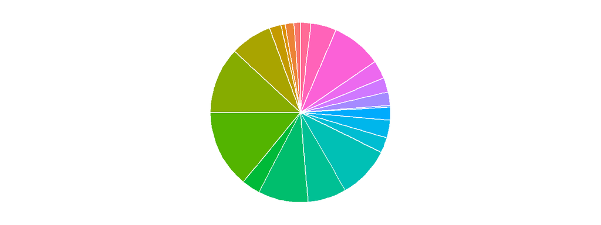

```r
hab_counts <- as.data.frame(table(reef$habitat))
names(hab_counts) <- c("habitat", "n")

ggplot(hab_counts, aes(x = "", y = n, fill = habitat)) +
  geom_col(width = 1, colour = "white") +
  coord_polar(theta = "y") +
  theme_void() +
  theme(legend.position = "none")
```

And that is **before** the legend, which would need 21 entries to tell you which sliver is which.

## The same data, as bars

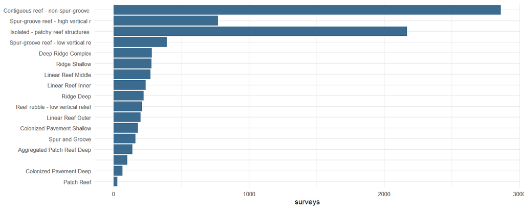

```r
hab_counts$habitat <- substr(hab_counts$habitat, 1, 34)

ggplot(hab_counts, aes(x = n, y = reorder(habitat, n))) +
  geom_col(fill = "#3B6B8F") +
  theme_minimal(base_size = 8) +
  labs(x = "surveys", y = NULL)
```

## The rule

**A pie is defensible when** you have two or three categories, they genuinely sum to a whole, and you only need the reader to see “about half” or “about a quarter”.

. . .

**It is not defensible when** there are more than about five categories, when slices need to be compared precisely, or when you want the reader to compare across two pies. Those are all bar chart jobs.

. . .

The protection pie above is at the edge of acceptable. The habitat one is not, and no palette would have saved it.

# Part 4: What the research actually says

## Has that 1984 ranking held up?

Broadly, yes. Heer and Bostock re-ran the experiments with crowdsourced participants and recovered an ordering close to the original, while extending it to rectangular areas (treemaps, cartograms) and circular ones (bubble charts).

. . .

So the hierarchy is not 1980s folklore. It replicates.

. . .

What has changed is the **question**. “Which chart type is best?” turned out to be narrower than people treated it as.

Heer, J. and Bostock, M. (2010). Crowdsourcing graphical perception: using Mechanical Turk to assess visualization design. *CHI ’10*, 203-212. doi:10.1145/1753326.1753357

## Effectiveness depends on the task

Saket, Endert and Demiralp compared five everyday chart types, table, line, bar, scatterplot and pie, across **ten different analysis tasks** on real datasets.

. . .

Effectiveness shifted meaningfully from task to task, and several chart types were competitive on many of them. There was no single winner.

. . .

So the question worth asking is not “what is the best chart” but **“what do I want the reader to do with it?”** Read one value. Compare two groups. Find the maximum. Spot a cluster. Judge a trend. Those have different answers.

Cleveland and McGill answered one of those questions, comparing magnitudes, very well. It was never meant to answer all of them.

Saket, B., Endert, A. and Demiralp, C. (2019). Task-based effectiveness of basic visualizations. *IEEE Transactions on Visualization and Computer Graphics*. arXiv:1709.08546

## The newer question: what the reader concludes

The older work asked whether a reader can **decode** a number from a chart. The newer work asks what they **take away**, which is not the same thing and is often not what the designer intended.

That covers how uncertainty is shown, how a title frames the conclusion, how axis choices steer the eye, and how people reason about risk.

. . .

One concrete finding, for anyone presenting rates: use **absolute** rather than relative rates, and give probabilities as **counts** (“3 out of 10”) rather than percentages.

## Where to read the current state

If you read one thing, read this review. It is written for non-specialists and pulls together visual perception, graph comprehension and uncertainty, which mostly had not been talking to each other.

Franconeri, S.L., Padilla, L.M., Shah, P., Zacks, J.M. and Hullman, J. (2021). The science of visual data communication: what works. *Psychological Science in the Public Interest* 22(3), 110-161. doi:10.1177/15291006211051956

. . .

**The honest summary of all of it:** put the numbers you most want compared into position or length, be suspicious of confident design rules including the ones on these slides, and remember that the reader’s conclusion is the output you actually care about.

# Part 5: Combining panels

## patchwork

Save plots as objects, then combine them with `+`, `|` and `/`.

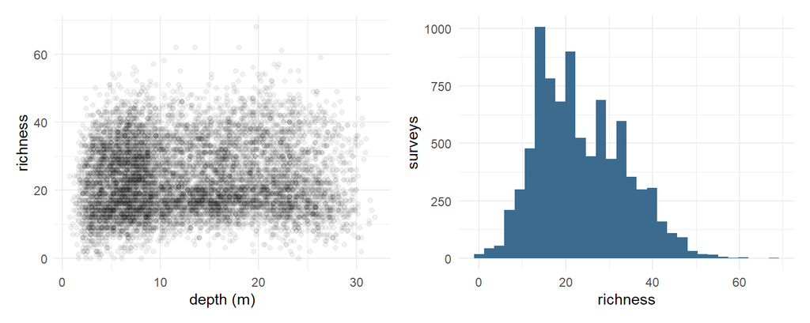

```r
a <- ggplot(reef, aes(depth, richness)) +
  geom_point(alpha = 0.06) + theme_minimal() + labs(x = "depth (m)", y = "richness")

b <- ggplot(reef, aes(richness)) +
  geom_histogram(bins = 30, fill = "#3B6B8F") + theme_minimal() +
  labs(x = "richness", y = "surveys")

a | b
```

## Layouts and labels

`|` puts plots side by side, `/` stacks them, and brackets group them. `plot_annotation()` adds the panel letters a reviewer will ask for.

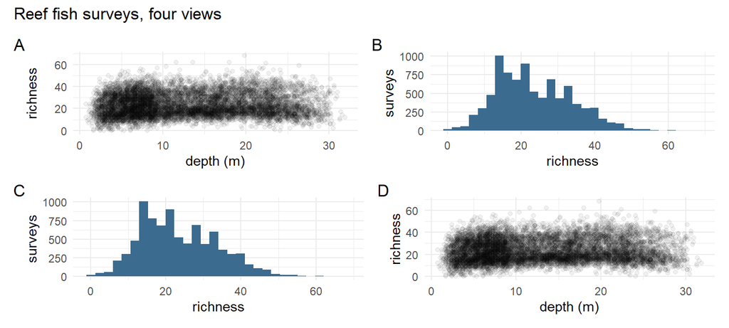

```r
(a | b) / (b | a) +
  plot_annotation(tag_levels = "A",
                  title = "Reef fish surveys, four views")
```

In a talk, build the same figure one panel at a time. In a paper, this is one figure instead of four.

# Part 6: Rank over time

## The naive version

`ggbump` draws rank changes as smooth curves. Here are the six commonest Florida birds in each year since 1997.

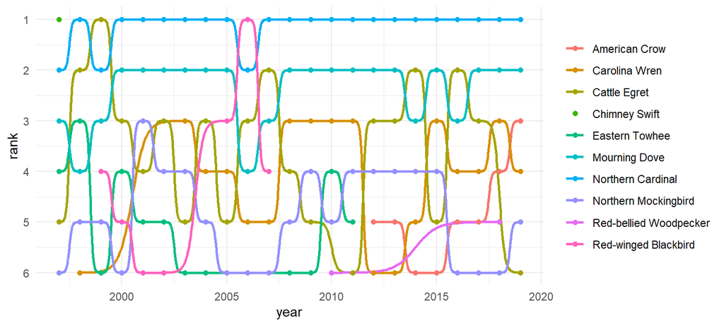

```r
ggplot(ranks, aes(year, rank, colour = common_name)) +
  geom_bump(linewidth = 1) +
  geom_point(size = 1.6) +
  scale_y_reverse(breaks = 1:6) +
  theme_minimal() +
  labs(y = "rank", colour = NULL)
```

## That figure is a mess, and it is instructive

Ten species, ten colors, a legend that forces the reader to look back and forth, and so many crossings that no line can be followed.

The problem is not the chart type. It is that the figure is trying to say ten things at once.

**A figure should make one point.** Decide what the point is, then make everything that is not the point recede.

Here is a point worth making: **the Chimney Swift was the commonest bird in Florida in 1997 and never appeared in the top six again.**

## The same data, one point

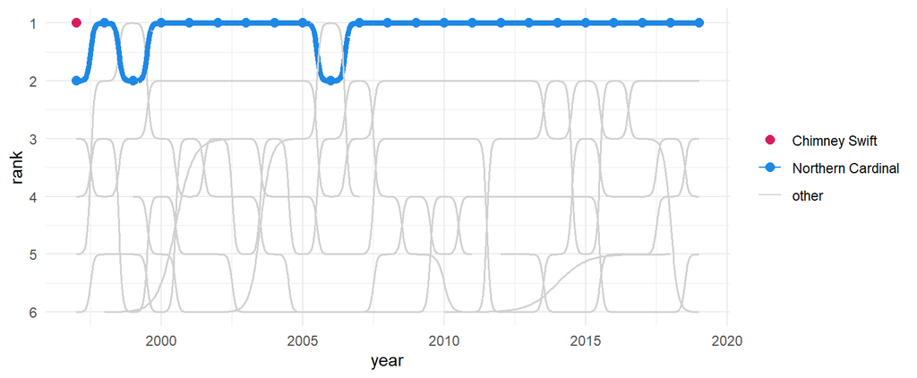

```r
highlight <- c("Chimney Swift", "Northern Cardinal")
ranks$focus <- ifelse(ranks$common_name %in% highlight, ranks$common_name, "other")

ggplot(ranks, aes(year, rank, colour = focus, group = common_name)) +
  geom_bump(aes(linewidth = focus != "other")) +
  geom_point(data = subset(ranks, focus != "other"), size = 2.4) +
  scale_y_reverse(breaks = 1:6) +
  scale_colour_manual(values = c("Chimney Swift" = "#D81B60",
                                 "Northern Cardinal" = "#1E88E5",
                                 "other" = "grey82")) +
  scale_linewidth_manual(values = c(0.6, 1.6), guide = "none") +
  theme_minimal() +
  labs(y = "rank", colour = NULL)
```

## The technique, which generalizes

Three lines did the work, and they work on any plot type:

1. Make a column that holds the series name for the few you care about and a constant like `"other"` for everything else
2. `scale_colour_manual()` with real colors for those few and a pale grey for `"other"`
3. Make the highlighted series thicker

The greyed lines are still there, so the reader can see the context and check that nothing has been hidden. They just stop competing.

**This one technique will improve more of your figures than any palette choice.**

## Now check the story before you tell it

The figure says the Chimney Swift was number one and then vanished. Both halves are true, and the explanation is not the one you would guess.

This check needs the raw survey data rather than the summary, so it is the one place here that downloads the full file (15 MB, a few seconds):

```r
bbs <- read.csv(paste0("https://github.com/bmaitner/biometry_course/raw/",
                       "refs/heads/main/data/BBS/FL_BBS.csv"))

swifts_97 <- bbs$total_sightings[bbs$Scientific_Name == "Chaetura pelagica" &
                                   bbs$Year == 1997]

sort(swifts_97, decreasing = TRUE)[1:6]
```

```
[1] 3166   54   48   31   30   29
```

One route recorded **3,166 swifts**. The next highest recorded 54.

## What that means

Chimney Swifts roost communally, pouring into a single chimney by the thousand at dusk. One observer, on one morning, on one route, hit a roost.

That single number made the species the commonest bird in Florida for one year in this figure. The 1998 “collapse” to 474 birds is not a population crash. It is the absence of that chimney.

**Two lessons, and the second is the general one:**

- A **bump chart shows rank and hides magnitude**. Rank 1 and rank 2 may be nearly tied, or differ tenfold, and the chart looks identical
- **Any dramatic pattern deserves one check before it becomes a sentence.** Sort the raw numbers. It takes thirty seconds and it is the difference between a finding and an embarrassment

# Part 7: Showing a model

## The gap this fills

By the end of Chapter 6 you can fit a model and report parameters. A table of parameters convinces nobody. A figure showing the fitted model over the data is what makes a result believable, and it is the first thing a reviewer looks for.

The recipe has three steps, and it is the same for every model you will fit:

1. **Make a grid** of covariate values to predict at
2. **Compute the prediction** at each, from the fitted parameters
3. **Plot the data, then the prediction on top**

## Step 0: fit something

The bobwhite occupancy model from Lecture 16: the probability a route holds bobwhite declines logistically with year.

```r
nll <- function(par){
  p <- plogis(par[1] + par[2] * occ$elapsed)
  -sum(dbinom(occ$n_occupied, size = occ$n_routes, prob = p, log = TRUE))
}

fit <- optim(c(a = 2, b = -0.05), nll, method = "BFGS", hessian = TRUE)

round(fit$par, 4)
```

```
      a       b
 2.0177 -0.0619
```

## Steps 1 and 2: predict over a grid

```r
pred <- data.frame(elapsed = seq(0, 22, length.out = 100))

pred$fit <- plogis(fit$par[1] + fit$par[2] * pred$elapsed)

head(pred, 3)
```

```
    elapsed       fit
1 0.0000000 0.8826417
2 0.2222222 0.8812094
3 0.4444444 0.8797619
```

The grid is finer than the data on purpose: 100 points draw a smooth curve, whereas predicting only at the observed years draws a polygon.

## Step 3: the figure

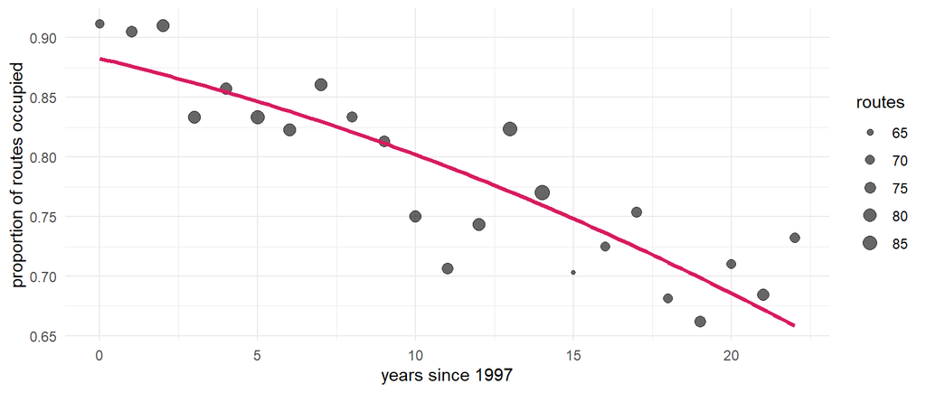

```r
occ$prop <- occ$n_occupied / occ$n_routes

ggplot(occ, aes(elapsed, prop)) +
  geom_point(aes(size = n_routes), alpha = 0.6) +
  geom_line(data = pred, aes(elapsed, fit), colour = "#D81B60", linewidth = 1.2) +
  scale_size_continuous(range = c(1, 4), name = "routes") +
  theme_minimal() +
  labs(x = "years since 1997", y = "proportion of routes occupied")
```

Point size carries sample size, so a year based on 64 routes does not look as authoritative as one based on 87.

## Adding uncertainty

A curve with no band implies a precision you do not have. `optim(hessian = TRUE)` gives you what you need: the curvature of the likelihood surface, which is the subject of Lecture 17.

```r
vcov_mat <- solve(fit$hessian)

round(sqrt(diag(vcov_mat)), 4)        # standard errors of a and b
```

```
     a      b
0.1289 0.0093
```

Then simulate parameter pairs from that uncertainty, build one curve per pair, and take the middle 95% at each x. This is Lecture 13’s simulation idea, used for a new purpose.

## The band, in six lines

```r
set.seed(1)
draws <- MASS::mvrnorm(2000, mu = fit$par, Sigma = vcov_mat)

curves <- apply(draws, 1, function(par){
  plogis(par[1] + par[2] * pred$elapsed)
})

pred$lo <- apply(curves, 1, quantile, 0.025)
pred$hi <- apply(curves, 1, quantile, 0.975)
```

`curves` is a 100 by 2000 matrix: one row per grid point, one column per simulated parameter pair. The quantiles are taken **across** simulations, at each grid point.

## The finished figure

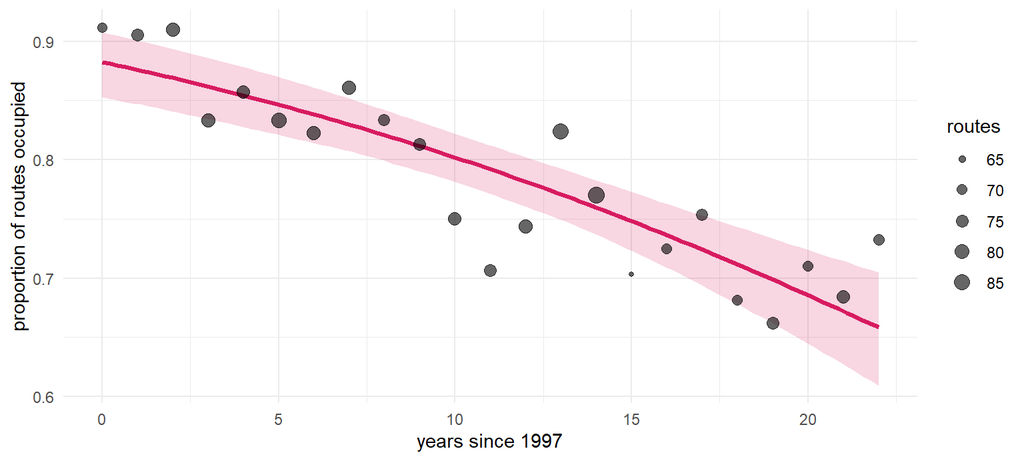

```r
ggplot(occ, aes(elapsed, prop)) +
  geom_ribbon(data = pred, aes(x = elapsed, ymin = lo, ymax = hi),
              inherit.aes = FALSE, fill = "#D81B60", alpha = 0.18) +
  geom_line(data = pred, aes(elapsed, fit), colour = "#D81B60", linewidth = 1.2) +
  geom_point(aes(size = n_routes), alpha = 0.6) +
  scale_size_continuous(range = c(1, 4), name = "routes") +
  theme_minimal() +
  labs(x = "years since 1997", y = "proportion of routes occupied")
```

## Read the band, not just the line

The band is **narrowest in the middle** of the data and widens toward both ends. That is not a quirk of this dataset, it is what fitting a line does: the fitted line pivots around the center of the data, so small changes in slope move the ends a lot and the middle hardly at all.

Two consequences worth carrying around:

- **Extrapolation is worse than it looks.** Extend the x axis and the band widens fast
- **The ends of your data are the weakest part of your model**, which is exactly where people like to read trends off a figure

```r
round(c(width_1997 = diff(c(pred$lo[1], pred$hi[1])),
        width_2008 = diff(c(pred$lo[50], pred$hi[50])),
        width_2019 = diff(c(pred$lo[100], pred$hi[100]))), 3)
```

```
width_1997 width_2008 width_2019
     0.055      0.041      0.096
```

## The same recipe, any model

Nothing above was specific to a logistic curve or a binomial. For the negative binomial count model from Lecture 16, only the middle line changes:

```r
# grid
pred <- data.frame(frac_built = seq(0, 0.5, length.out = 100))

# prediction: the deterministic function, with the fitted parameters
pred$fit <- fit$par["mu0"] * exp(fit$par["b"] * pred$frac_built)

# plot: data, then prediction on top
ggplot(counts, aes(frac_built, count)) +
  geom_point(alpha = 0.15) +
  geom_line(data = pred, aes(frac_built, fit), colour = "#D81B60")
```

Grid, predict, plot. The model changes; the recipe does not.

# Part 8: The frame around the data

## Everything that is not your data

A **theme** controls the frame: panel background, grid lines, axis text, tick marks, legend position, borders, margins. It cannot change a single plotted value, which is what makes it safe to experiment with.

The payoff is not that a figure looks nicer. It is that a theme removes ink that is not carrying information, which leaves more attention for the ink that is.

## The built-in themes

| Theme | What you get | Reach for it when |
| --- | --- | --- |
| `theme_grey()` | the default: grey panel, white grid | never on purpose |
| `theme_bw()` | white panel, grid, black border | a journal figure |
| `theme_minimal()` | white panel, grid, no border | a slide |
| `theme_classic()` | axis lines, no grid | one clean panel |
| `theme_void()` | nothing but the data | pies, maps |

There are also `theme_linedraw()`, `theme_light()` and `theme_dark()`, which you will rarely need. They all take the same arguments, so swapping one for another is a one-word edit. Try two before you settle.

## Four of them, same data

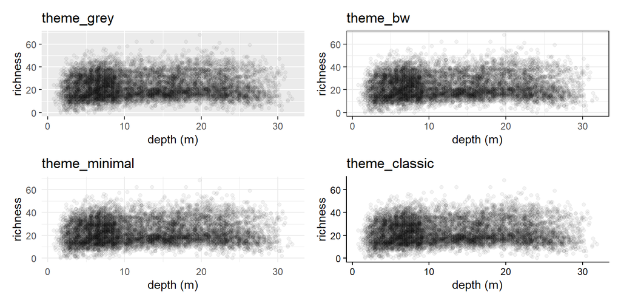

```r
pts <- ggplot(reef, aes(depth, richness)) +
  geom_point(alpha = 0.05) +
  labs(x = "depth (m)", y = "richness")

(pts + theme_grey()    + labs(title = "theme_grey") |
 pts + theme_bw()      + labs(title = "theme_bw")) /
(pts + theme_minimal() + labs(title = "theme_minimal") |
 pts + theme_classic() + labs(title = "theme_classic"))
```

## What that comparison shows

`pts` is one object. Adding a theme to it returns a modified copy, so those are the same figure dressed four ways and nothing about the data moved.

. . .

. . .

**`theme_bw()` and `theme_classic()` differ in what they keep.** A border tells the reader where the panel ends, which matters when panels sit side by side. Axis lines alone are cleaner, and get ambiguous in a multi-panel figure.

. . .

**`theme_minimal()` is the slide default** because a projector loses low-contrast detail, and a grid with no border is the least ink that still lets someone read a value off the axis.

## theme_void: no frame at all

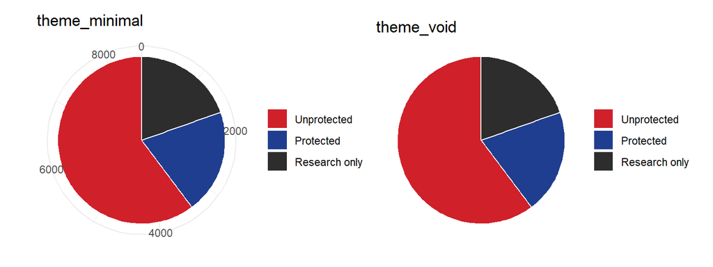

```r
pie_raw <- ggplot(prot_counts, aes(x = "", y = n, fill = protection)) +
  geom_col(width = 1, colour = "white") +
  coord_polar(theta = "y") +
  scale_fill_manual(values = prime) +
  labs(x = NULL, y = NULL, fill = NULL)

(pie_raw + theme_minimal() + labs(title = "theme_minimal")) |
  (pie_raw + theme_void() + labs(title = "theme_void"))
```

On the left, the axis numbers are cumulative counts and the grid lines are arcs. Neither means anything to a reader, which is why Part 3 used `theme_void()`.

## base_size

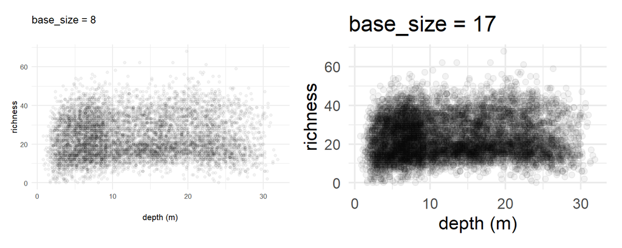

```r
(pts + theme_minimal(base_size = 8) + labs(title = "base_size = 8")) |
  (pts + theme_minimal(base_size = 17) + labs(title = "base_size = 17"))
```

The font size everything else is scaled from. The default, 11, is sized for a printed page: use roughly 14 to 18 on a slide, and 8 to 10 for one panel of a grid.

## Setting it once: theme_set()

Set the default at the top of a script, and every plot after it uses it:

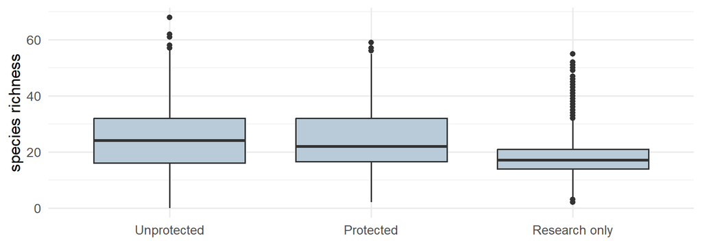

```r
theme_set(theme_minimal(base_size = 13))

ggplot(reef, aes(protection_f, richness)) +
  geom_boxplot(fill = "#B9CBD8") +
  labs(x = NULL, y = "species richness")
```

There is no theme call in that plot, which is the point.

## theme_set() lasts the session

It holds until you restart R or set something else. To go back to the ggplot2 default:

```r
theme_set(theme_grey())    # undo it, so the rest of this file is unaffected
```

For a manuscript, this is how every figure ends up matching without you checking each one: `theme_set()` in the first lines of the script, and no theme calls after that.

`theme_update()` is the gentler version. It changes one piece of the current default instead of replacing the whole theme.

## Theme elements

To change one piece of a theme, `theme()` takes a named argument per element, and the value is an `element_*()` function describing how to draw it:

| Function | For |
| --- | --- |
| `element_text()` | anything made of words: titles, axis labels, legend text |
| `element_line()` | grid lines, tick marks, axis lines |
| `element_rect()` | panels, plot background, legend boxes |
| `element_blank()` | delete it entirely |

Element names are a hierarchy: `axis.text.x` inherits from `axis.text`, which inherits from `text`. So setting the short name changes every piece under it:

```r
theme(text = element_text(family = "serif"))   # every piece of text at once
```

`?theme` lists all ninety or so names, of which you will use a dozen.

## Changing one thing

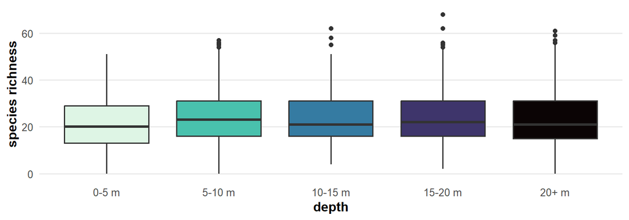

```r
ggplot(reef, aes(depth_class, richness, fill = depth_class)) +
  geom_boxplot() +
  scale_fill_viridis_d(option = "mako", direction = -1, guide = "none") +
  theme_minimal(base_size = 12) +
  theme(panel.grid.minor   = element_blank(),
        panel.grid.major.x = element_blank(),
        axis.title         = element_text(face = "bold")) +
  labs(x = "depth", y = "species richness")
```

`theme()` comes **after** `theme_minimal()`. Later layers win, so the other order silently throws your changes away.